# Sudan Maternal and Child Health and Nutrition Survey 2018

Anita Amponsa, Shylett Anthony, Naemi Araya, Moshood Audu, Rasika Bombatkar, Neira Budiono, Phillip Chigiya, Prince Kelechi Chima, John Bok Chol, Clifford Cofie, Eslam Elbasheer, Prateek Garg, Mary Gouws, Samvel Grigoryan, Marietta Imadojiemu, Jillian Francise Lee, Anita Makori, Joseph Mwaka, Kapil Narain, Josephine Ndawula, Thokozani Nyasulu, Richmonda Pearce, Mariano Ratto, Gloria Rukomeza, Mercedes Rumi, Amina Suveha, Shih-Ting Tseng, Claudia Vidal Cuellar, Yih Seong Wong

2024-03-06

## Background

Sudan has the third highest prevalence of acute malnutrition in the world and the highest in the Middle East and North Africa region at 16% global acute malnutrition amongst children under five years. The under-five mortality rate in the country was estimated at 68/1000 in 2014 compared with 108/1000 in 2000 for an annual rate of reduction of 2.2% since 1990. Access to primary health care (PHC) remains low despite the fact that the Integrated Management of Childhood Illnesses (IMCI) coverage at health facilities increased from 43 percent to 46.1 percent in 2013. Sudan’s low coverage of improved water and sanitation facilities continues to hamper overall child health and nutrition. The Simple Spatial Survey Method (S3M) is a large-scale survey method originally developed from the centric systematic area sampling (CSAS) coverage survey method as a response to the widespread adoption of community management of acute malnutrition (CMAM) by ministries of health. From its initial application as a coverage survey method, S3M’s potential for use in national-scale multi-indicator surveys was considered and explored. Sudan supported the development of the method for this broader application through 2 state-level pilots in Gedaref and Sennar in 2012 which eventually led to the first national S3M survey in Sudan in 2013 to measure a range of indicators (health, WASH and nutrition) over small geographical areas, giving results at locality level and lower. It provided comprehensive information at state level and lower that was used to target and re-align interventions. The experience from the Sudan S3M I (2013) has shown that mapping variation and thus identifying areas of high need has allowed evidence-based targeting of interventions to most vulnerable populations, enabling improved cost-benefit in the current context of diminishing funding resources in Sudan. The S3M I contributed to planning of humanitarian and other responses to target the most vulnerable communities at locality level and below over the last 2-3 years in Sudan. For instance, the results were used for the mid-year revision of the 2014 Humanitarian Needs Overview (HNO) for all sectors enabling, for the first time, the use of locality level information for targeting responses, as well as acting as a catalyst for multi-sectoral programming. In addition, the S3M I survey results contributed to establishing the UNICEF programmatic shift to intervening in high-priority localities and it also helped the Government of Sudan to prioritize localities most in need.

The S3M II has been carried out in 2018 in order to obtain updated and comprehensive data for nutrition, health, WASH and child protection indicators. It includes data for smaller geographical areas within localities as well as from the national, state, and locality level for children and their mothers in Sudan. It intends to identify the areas where the highest need are to allow evidence based program planning and targeting for equity to enable a better and more effective use of scarce resources for humanitarian response and enhanced impact within Sudan.

### Objectives

This report builds on the data from the S3M II and provides further analysis of the data that has not been done in the initial reporting of the findings. Specifically, this report aims to:

1. Demonstrate the bottlenecks/barriers to service delivery of essential maternal care such as antenatal and postnatal care;
2. Demonstrate the bottlenecks/barriers to service delivery of the expanded programme on immunisation (EPI);
3. Demonstrate the bottlenecks/barriers to basic pre-school education;
4. Map the spatial distribution of child and maternal undernutrition;
5. Assess the responsiveness of the community-based management of acute malnutrition (CMAM) programme; and,
6. Determine the predictors of child and maternal undernutrition.

## Bottlenecks to maternal care service delivery

### Description of analytical approach

### Results

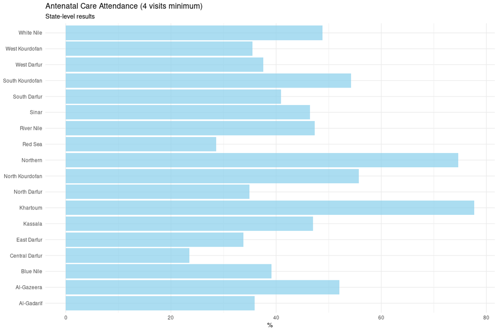

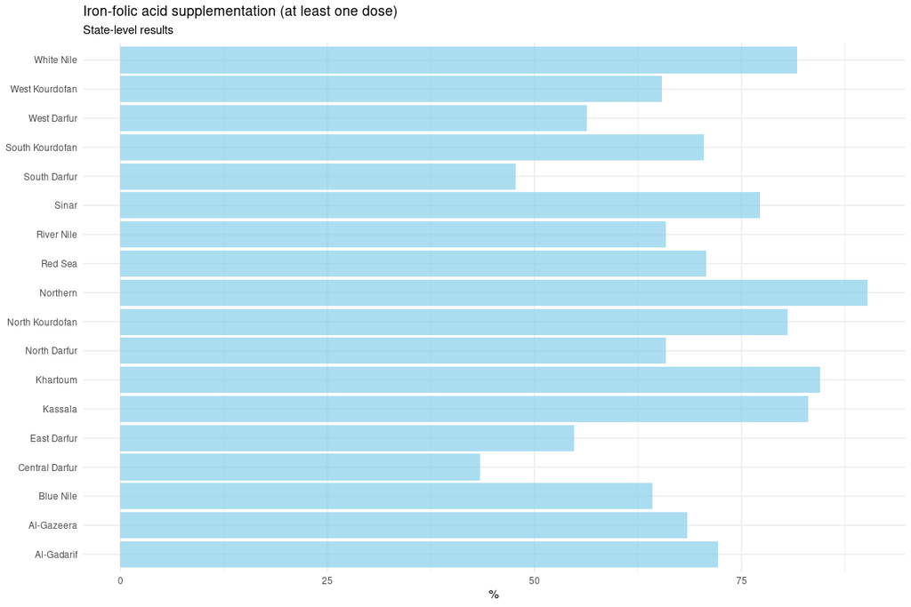

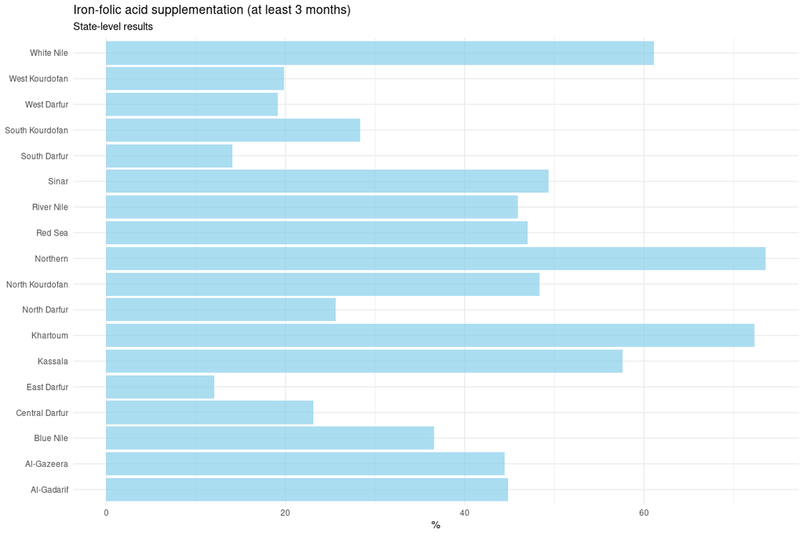

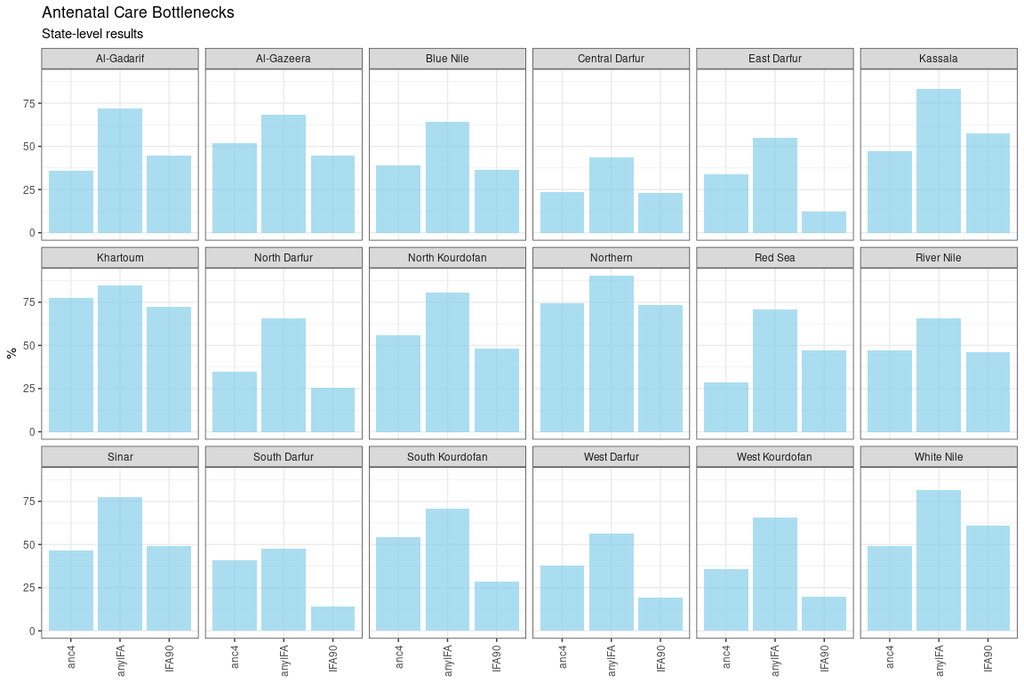

### Discussion

- Sudan’s capital, Khartoum had the highest (78%) ANC attendance of at least 4 visits as recommended by the WHO while Central Darfur, a conflict area had the lowest.
- There are notable discrepancies between the number of women who received at least one dose of iron/folic acid supplements and those who received prescriptions each month up to 90 days. This demonstrates that a significant proportion of women successfully enrolled into antenatal care are lost to follow-up often within the first 3 months.
- Antenatal bottlenecks are observed across all states in Sudan. The most affected regions are East Darfur and West Kourdofan states where about 46% of all women enrolled in antenatal care are lost to follow up. The least affected region is Khartoum with only about 12% of all women enrolled in the state.

### Recommendations

- Further research is needed to explore barriers and facilitators to successful completion of antenatal care to inform health system interventions in Sudan.
- Areas most affected by bottlenecks such as central Dafur, East Dafur and West Kourdofan should be prioritised for these interventions.

## Bottlenecks to EPI coverage

### Description of analytical approach

### Results

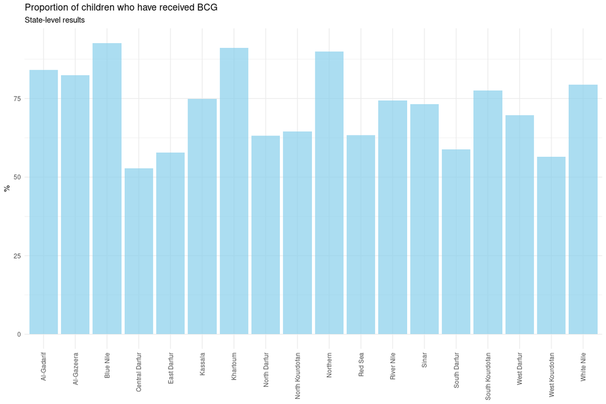

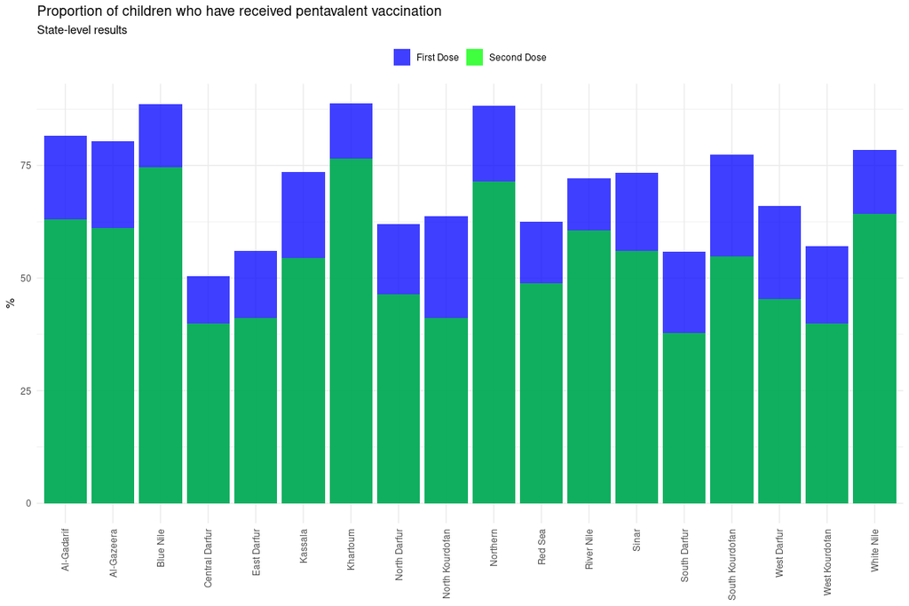

### Discussion

### Recommendations

## Barriers to basic pre-school education

### Results

Individual factors

| **Characteristic** | **0**, N = 17,040<sup>1</sup> | **1**, N = 9,521<sup>1</sup> |
| --- | --- | --- |
| age | 4 (4, 4) | 4 (4, 4) |
| sex |  |  |
| 1 | 8,616 (51%) | 4,643 (49%) |
| 2 | 8,424 (49%) | 4,878 (51%) |

<sup>1</sup> Median (IQR); n (%)

Health-related factors

| **Characteristic** | **No**, N = 17,040<sup>1</sup> | **Yes**, N = 9,521<sup>1</sup> | **Missing Response Status**, N = 112,596<sup>1</sup> |
| --- | --- | --- | --- |
| Having Vaccine Record | 116 (57%) | 82 (69%) | 36,124 (56%) |
| Unknown | 16,837 | 9,403 | 47,886 |
| History of Diarrhea | 2,543 (15%) | 1,201 (13%) | 26,530 (24%) |

<sup>1</sup> n (%)

Structural factors

| **Characteristic** | **No**, N = 17,040<sup>1</sup> | **Yes**, N = 9,521<sup>1</sup> | **Missing Response Status**, N = 112,596<sup>1</sup> |
| --- | --- | --- | --- |
| Health Insurance | 4,535 (27%) | 3,989 (42%) | 22,985 (20%) |
| Unknown | 30 | 13 | 130 |
| Displacement | 804 (4.7%) | 0 (NA%) | 0 (0%) |
| Unknown | 11 | 9,521 | 112,580 |
| School Far | 3,077 (18%) | 0 (NA%) | 6 (38%) |
| Unknown | 11 | 9,521 | 112,580 |

<sup>1</sup> n (%)

### Discussion

### Recommendations

## Spatial distribution of maternal and child undernutrition

The rates of stunting by state follow different patterns, however, compared to maternal undernutrition, child wasting and underweight. Child stunting is higher in the states of North, West and Central Dafur, Red Sea, Sinar and South Kourdofan (40% or higher).

Interestingly, there is not much overlap of stunting with the other forms of undernutrition per state, except for one state: South Kourdofan: where there are high rates of maternal undernutrition, child stunting, underweight and wasting.

### Desription of analytical approach

1. We first classified the nutrition status according to the WHO guidelines status by Z scores and for MUAC for mothers and Children under 5 respectively.
2. We then calculated the sum in percentages for all the categories of the nutrition statuses.
3. Merge the MAP Data and the shape file.
4. Plotted the map individually.
5. Used the patchwork to make the maps align to each other.

### Results

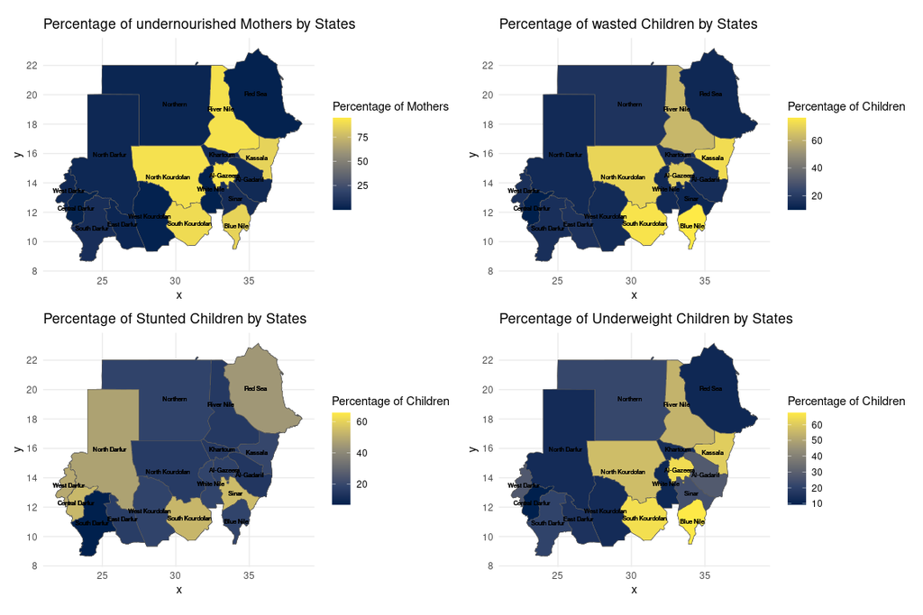

### Discussion

The types of under nutrition present in the states may represent differing underlying mechanisms of under nutrition. Stunting represents chronic under nutrition over a long period of time - thus indicating that in the states of high rates stunting there may be long-standing food insecurity.

In the states where there are higher rates of maternal under nutrition with child wasting and underweight without high rates of stunting, this may be more indicative of a more short-term under nutrition, such as a famine, with acute loss of weight.

In the state of South Kourdofan, there is a possible combination of chronic under nutrition, reflected by high rates of child stunting, as well as more acute complications too - high rates of child wasting and underweight as well as maternal under nutrition.

All interpretations need to be correlated with more information about the current geography, climate, political situation and food security in the country to further understand the complexity of the state of under nutrition.

### Recommendations

Based on the above findings, it will be necessary to further investigate the reasons for undernutrition which is concentrated in certain states.

Based on this, policy and interventions can be targeted to address these underlying causes, with a focus on the states worst affected by undernutrition.

South Kourdofan should be an important state to consider initially given the double burden of chronic and super-imposed acute undernutrition.

## CMAM programme responsiveness

### Description of analytical approach

CMAM is a programme that was implemented in Sudan to address acute malnutrition among children in all states of Sudan.

From the given dataset and background knowledge of the setting, we decided on four indicators to calculate and track over the 4-year period i.e cure rate, non-response rate, defaulter rate and death rate of children.

Changes over time in these indicators were plotted to enable an inference concerning the responsiveness of the CMAM programme to the problem of malnutrition in Sudan.

### Results

#### Total Results

| Performance Indicators | Values (%) |
| --- | --- |
| Cure Rate | 89.0% |
| Default Rate | 8.5% |
| Death Rate | 0.9% |
| Non Responder Rate | 1.6% |
| Admitted Rate | 8.3% |

#### Total by Year

| Year | No. of Admissions | No. of Defaulters | Cure Rate | Death Rate | Default Rate | Non-response Rate |
| --- | --- | --- | --- | --- | --- | --- |
| 2016 | 224632 | 23558 | 85.6% | 1.2% | 11.6% | 1.6% |
| 2017 | 227419 | 20259 | 88.0% | 0.9% | 9.5% | 1.6% |
| 2018 | 244796 | 16159 | 90.4% | 0.8% | 7.2% | 1.6% |
| 2019 | 250568 | 14479 | 91.4% | 0.8% | 6.2% | 1.6% |

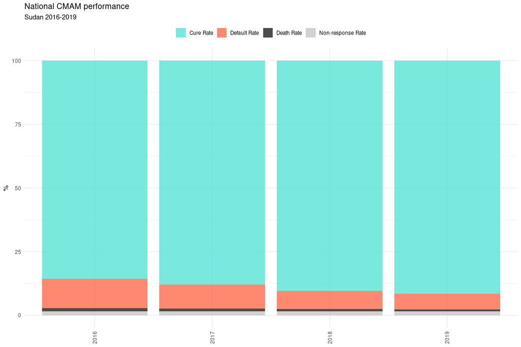

#### Indicator by Year and State

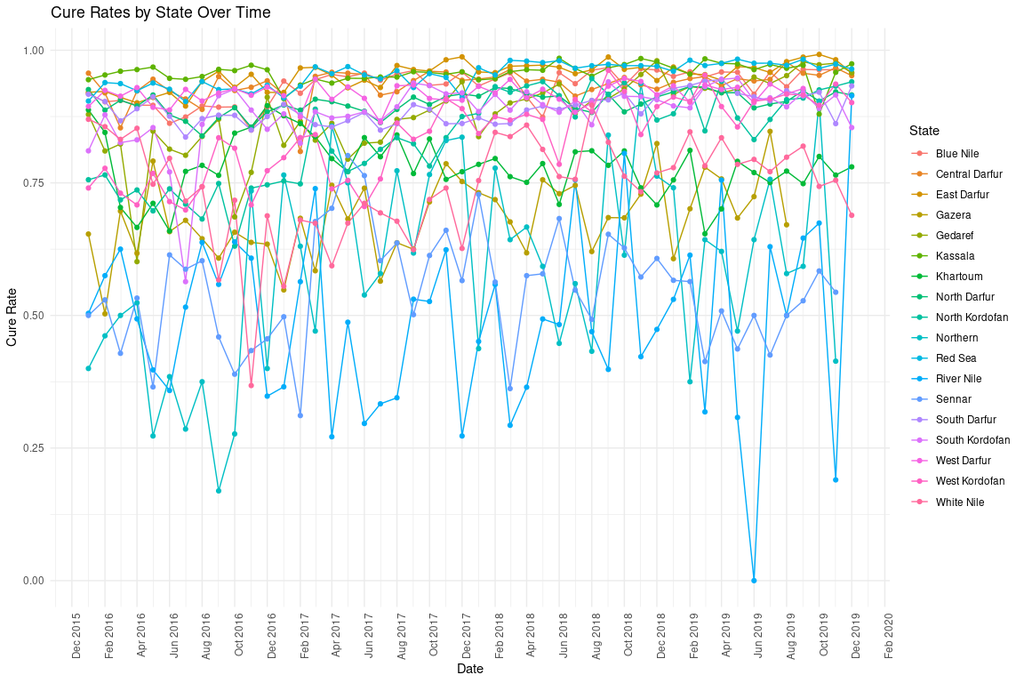

#### Admissions and Defaulters by Year

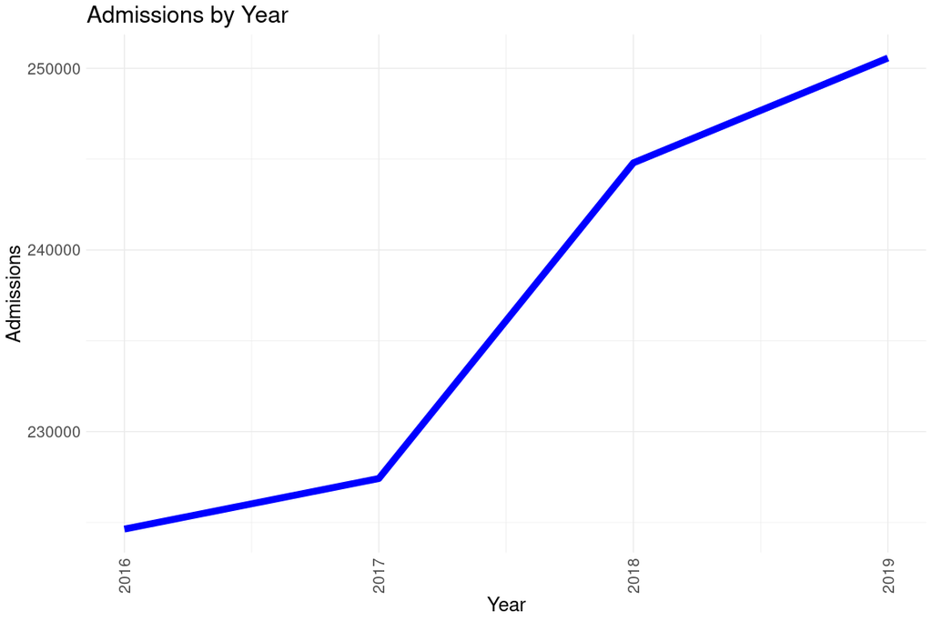

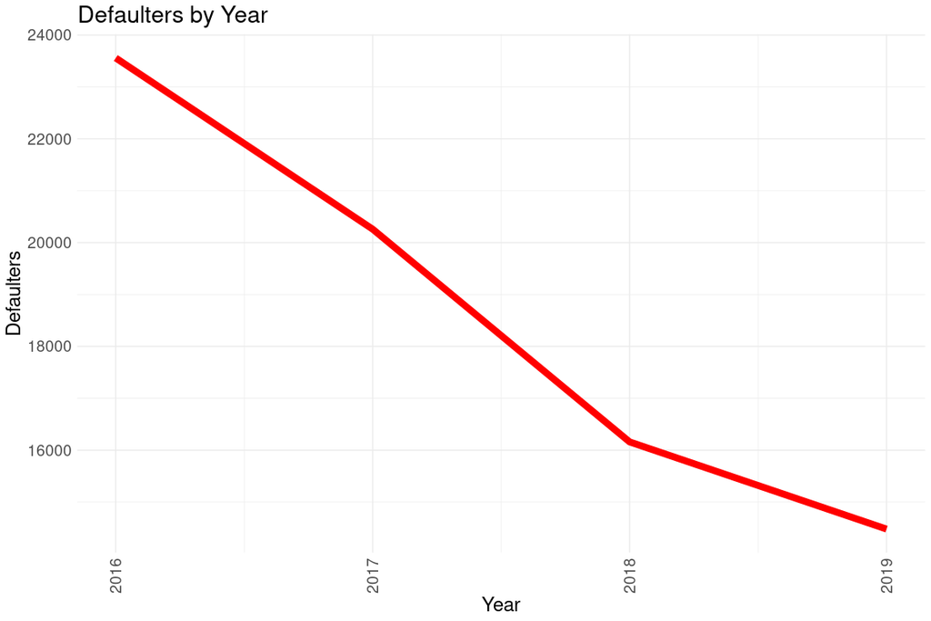

### Recommendations

1. Government should reduce missing data during routine data collection.
2. Community management of acute malnutrition should continue to be offered by the government.
3. Cure rate seems to be going up, but some states still need assistance in bringing up the cure rate.
4. Strengthen the community management of acute malnutrition in states with low cure rate and high defaulters.

## Determinants of maternal and child undernutrition

### Discussion

### Recommendations